# Civitas Meeting

Evelyn Cai

9/10/2020

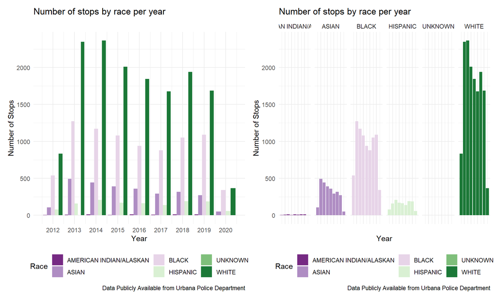

## Disparity Ratio Calculations

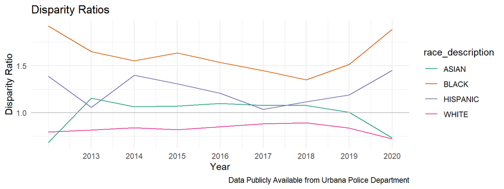

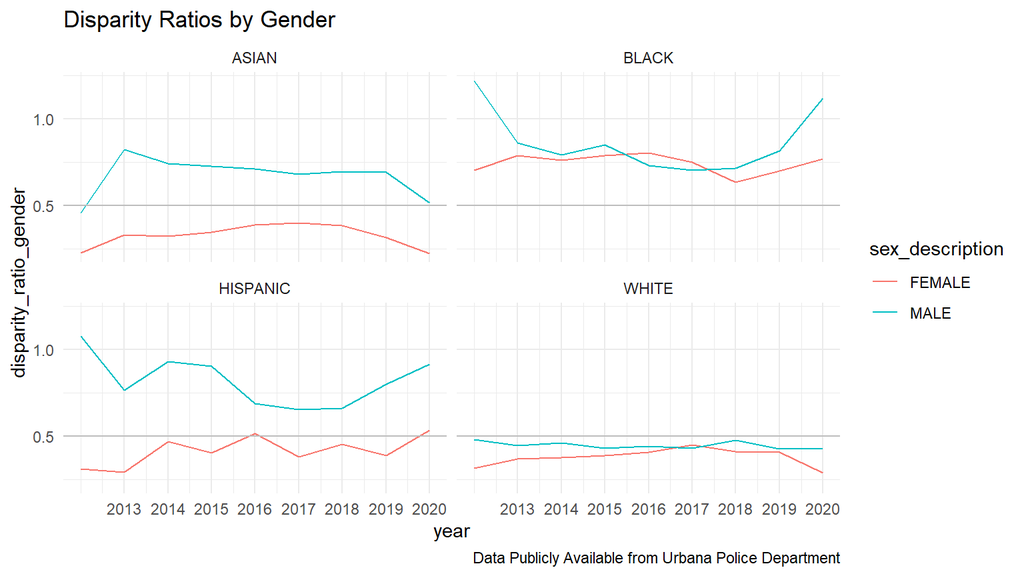

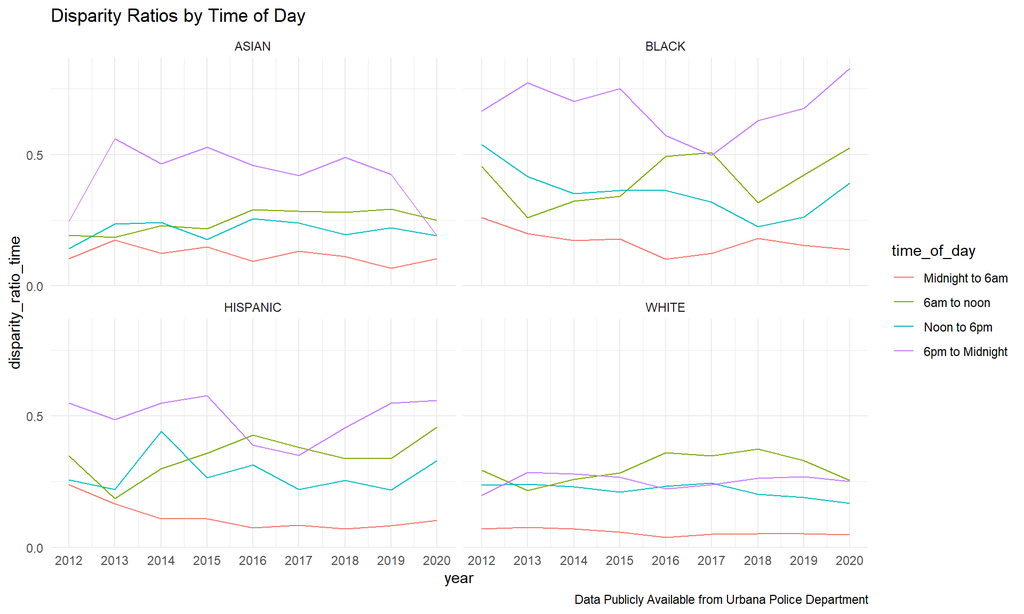

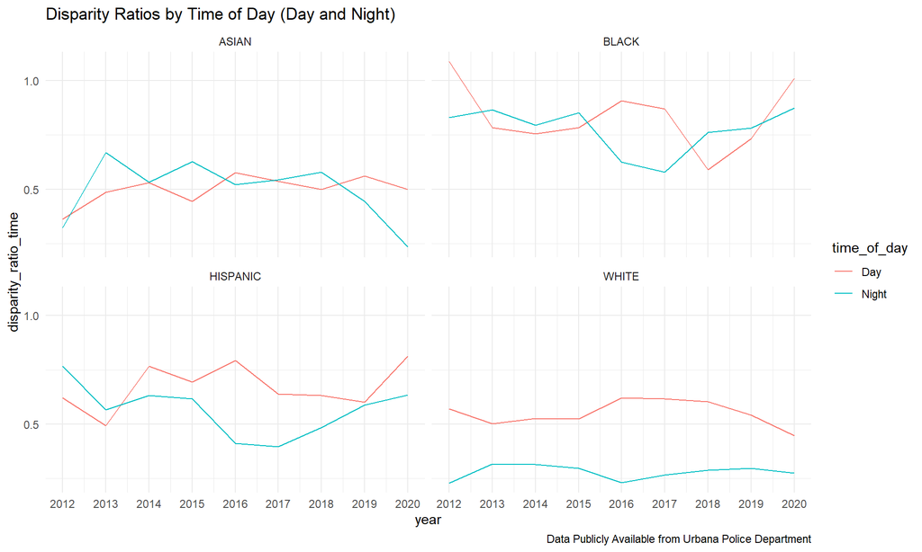

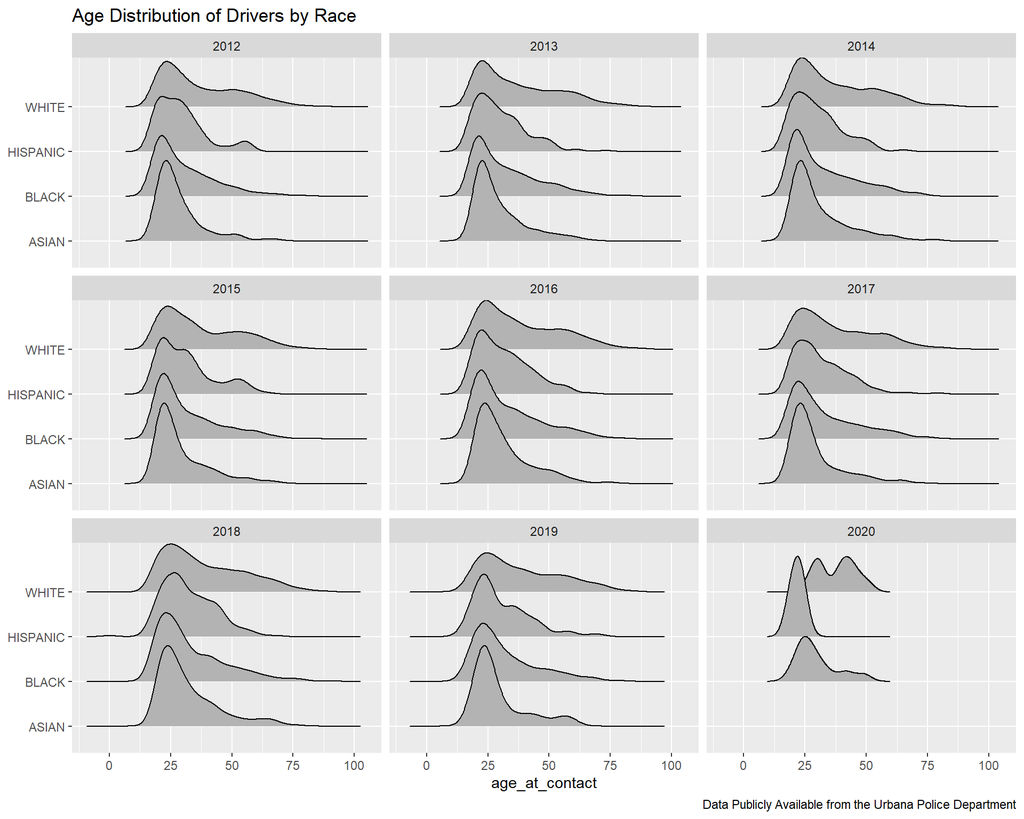

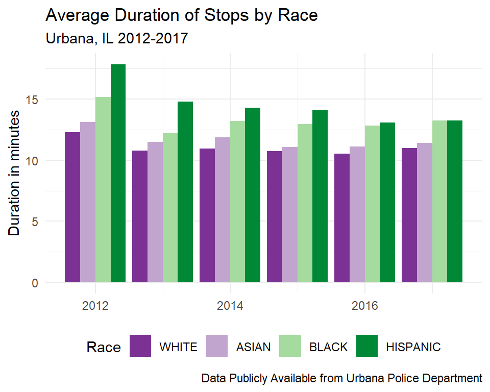

As you can see from the graph above, average durations are higher for all POC groups than white folks. Over time, average duration seems to have decreased. However, Black and Hispanic drivers’ durations in 2017 are still on average longer than Asian and white drivers’ durations in 2012, indicating that whatever racial gap is evident here has yet to be closed.

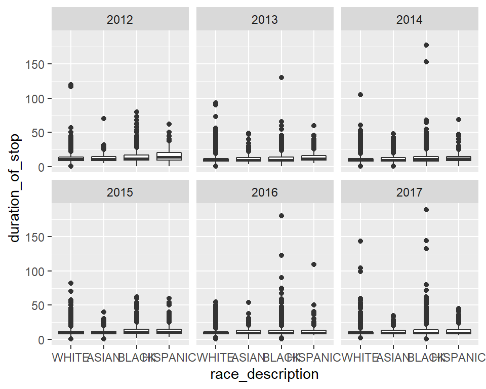

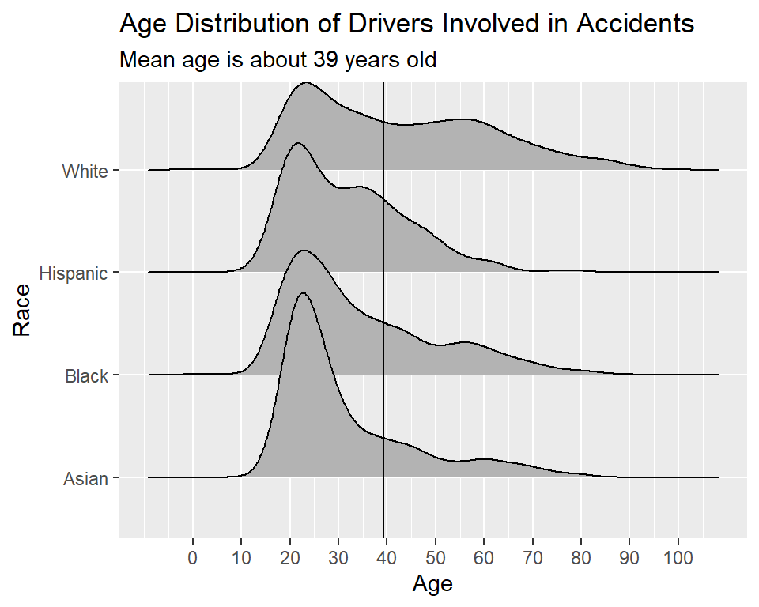

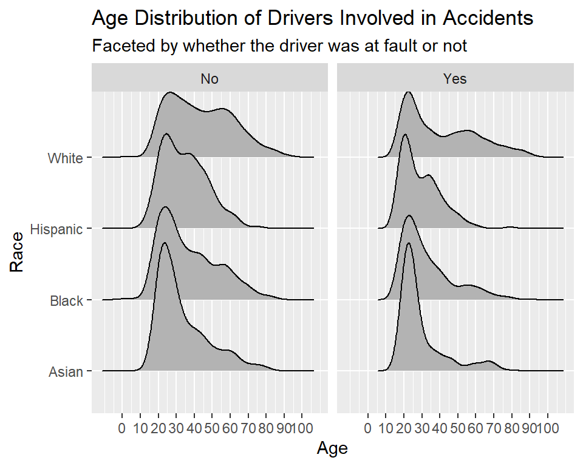

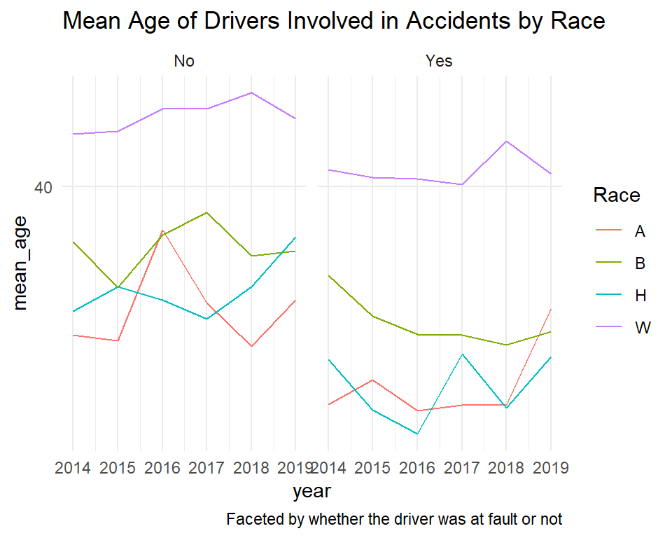

```
## # A tibble: 97 x 5
##    Race  Sex   `At Fault`  year prop_at_fault
##    <chr> <chr> <chr>      <dbl>         <dbl>
##  1 B     M     No          2014         0.476
##  2 W     M     No          2014         0.596
##  3 W     F     Yes         2014         0.438
##  4 H     F     No          2014         0.45
##  5 B     M     Yes         2014         0.524
##  6 W     M     Yes         2014         0.404
##  7 B     F     Yes         2013         1
##  8 B     F     Yes         2014         0.508
##  9 A     M     Yes         2014         0.506
## 10 W     F     No          2014         0.562
## # ... with 87 more rows
```

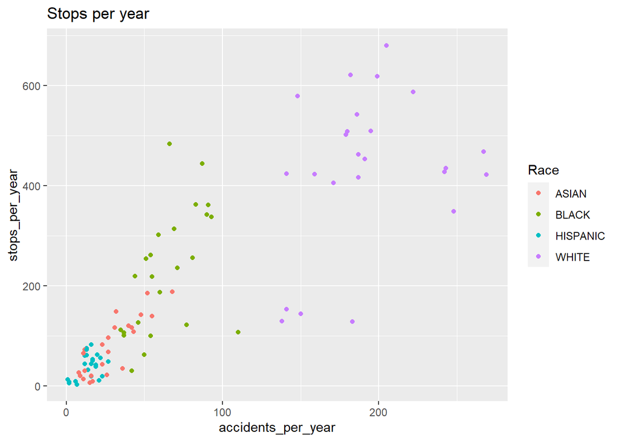

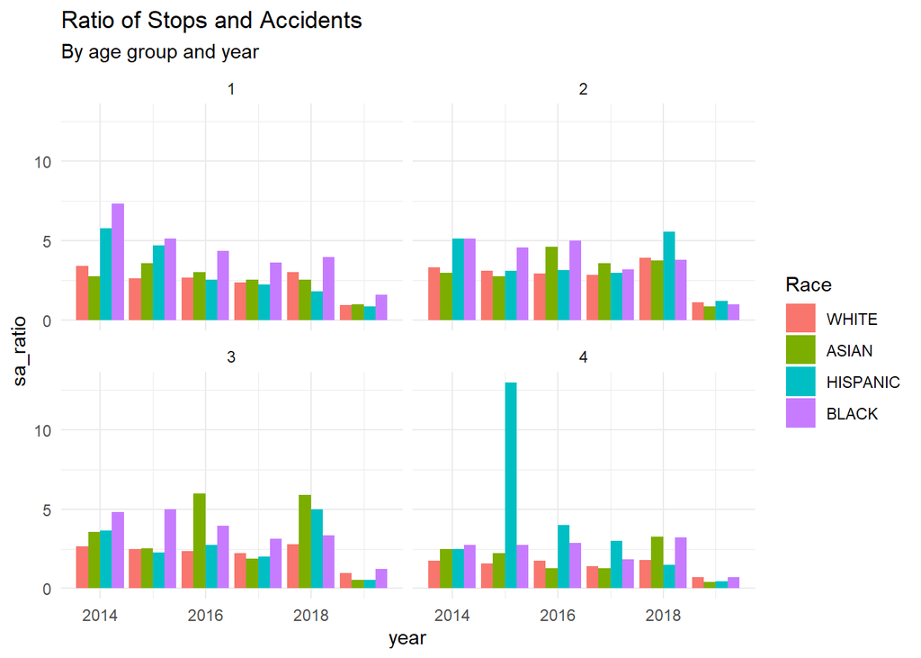

```
## stan_glm
##  family:       gaussian [identity]
##  formula:      stops_per_year ~ Race + Age + year
##  observations: 96
##  predictors:   6
## ------
##              Median  MAD_SD
## (Intercept)  60196.5  9677.0
## RaceBLACK      147.6    22.2
## RaceHISPANIC   -41.2    23.0
## RaceWHITE      353.1    23.8
## Age            -39.6     7.5
## year           -29.8     4.8
##
## Auxiliary parameter(s):
##       Median MAD_SD
## sigma 80.0    5.7
##
## ------
## * For help interpreting the printed output see ?print.stanreg
## * For info on the priors used see ?prior_summary.stanreg
```

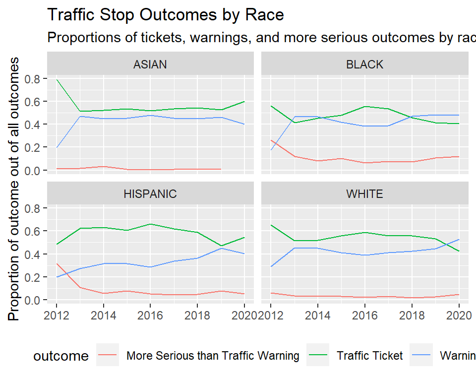

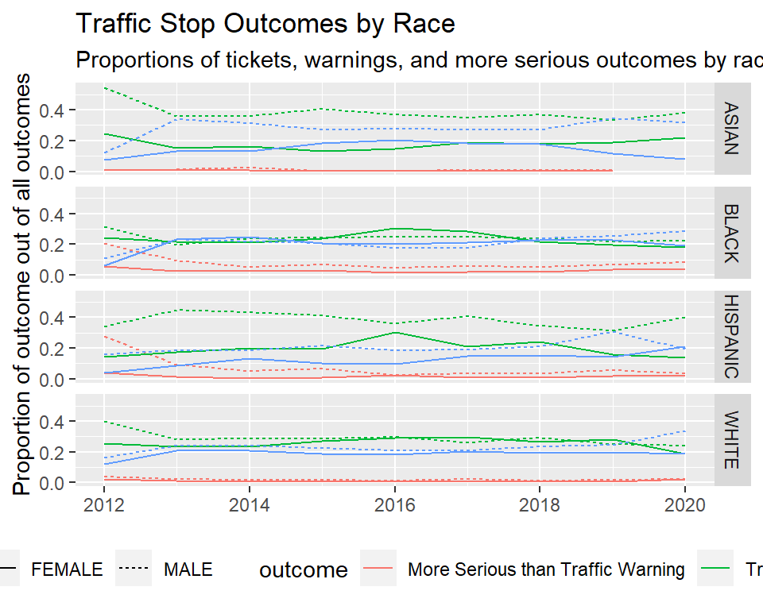

# Notes from 9/4 meeting

- bar graphs
- accidents vs stops for race and age - putting age into buckets (like 16-24)
- pages on methodology

# Questions

- Which variable reveals the outcome of the stop, and which outcomes are considered “more serious than traffic violations”? (Is it crime category description: traffic offenses?)
- Which variable, and which levels of that variable, reveal an arrest outcome for traffic stops?
- Where can I get the duration of each traffic stop?
- What are meaningful time segmentations? (morning/night, light/dark, rush hour/ non, etc)
- Anything you want to be looked at?